# IODS course project

Nita Mettinen

# Introduction to Open Data Science - Course Project

# About the project

# Feelings about the course right now and some expectations

There was more basic R practises in the beginning of the course than I expected when I signed up for the course. However, it seems that I may learn to use some new tools, such as tibble and tools used in its formatting during the course.

```r
# This is a so-called "R chunk" where you can write R code.

date()
```

```
## [1] "Tue Dec 12 03:38:55 2023"
```

# My learning experiences with the R for Health Data Science book and the Exercise Set 1

I have been processing data mostly using data frames, but I found it quite refreshing to explore new tools to handle data with the tibble and useful functions introduced. I am quite familiar with R, so I was able compare the new tools to those I have already used and get to know or even some way learn that way the usage of the more modern tools. My favorite topic was ggplot because I have not thoroughly learned the basics of ggplot visualization tools before, although I consider it a very important tool for creating advanced data visualization. At the same time, I thought that the ggplot was the most difficult topic.

# Link to my github repo

https://github.com/nitaHY/IODS-project

# 2: Regression and model validation

```r
date()
```

```
## [1] "Tue Dec 12 03:38:55 2023"
```

## 1. Reading the data in

```r
#libraries needed:
library(dplyr)

#reading in a subsample of the learning2014 data created earlier in the data wrangling part
students2014 = read.csv("data/learning2014.csv", header = TRUE)

#structure of the data:
str(students2014)
```

```
## 'data.frame':    166 obs. of  7 variables:
##  $ gender  : chr  "F" "M" "F" "M" ...
##  $ Age     : int  53 55 49 53 49 38 50 37 37 42 ...
##  $ Attitude: int  37 31 25 35 37 38 35 29 38 21 ...
##  $ deep    : num  3.58 2.92 3.5 3.5 3.67 ...
##  $ stra    : num  3.38 2.75 3.62 3.12 3.62 ...
##  $ surf    : num  2.58 3.17 2.25 2.25 2.83 ...
##  $ Points  : int  25 12 24 10 22 21 21 31 24 26 ...
```

```r
#mostly numeric data included in the variables, but gender-column includes character vector variable that gets values F and M

#dimensions of the data
dim(students2014)
```

```
## [1] 166   7
```

```r
#there are 166 rows = data from 166 students and 7 columns = variables included in the data
```

### Description of the students2014-dataset

This students2014-data is an earlier created subset of a learning questionnaire data from [here](http://www.helsinki.fi/~kvehkala/JYTmooc/JYTOPKYS3-data.txt). More information about the contents can be found from [here](http://www.helsinki.fi/~kvehkala/JYTmooc/JYTOPKYS3-meta.txt). In short, in the original data, there are individual students’ answers to the questionnaire including questions about learning and attitudes towards learning statistics. In addition, there are basic information about the students, such as gender, age and degree, time used for studying, number of courses studied at the moment of answering and the year of studies. From this data I extracted a part that includes only age, gender, attitude and points from the original data and also three summary variables, deep, stra and surf, which refer to deep, strategic or surface learning approaches and are mean values of certain original variables defined [here](http://www.helsinki.fi/~kvehkala/JYTmooc/JYTOPKYS3-meta.txt) in more detail.

## 2. Summary of the variables and their relationships

By plotting histograms and qq-plots I can deduce if the distributions of the variables are normal or not and use this information for example when choosing the statistical tests. Boxplots and numerical summaries also show the range of values around the mean but also show potential outliers to be excluded from the analyses. Normally distributed variables (or if they can be at least transformed to normally distributed) can be quite safely used as dependent variables in the linear regression models. Outliers may distort results so they should be noticed and possibly removed from the data before analysis. ### Summaries of the variables

```r
summary(students2014)
```

```
##     gender               Age           Attitude          deep
##  Length:166         Min.   :17.00   Min.   :14.00   Min.   :1.583
##  Class :character   1st Qu.:21.00   1st Qu.:26.00   1st Qu.:3.333
##  Mode  :character   Median :22.00   Median :32.00   Median :3.667
##                     Mean   :25.51   Mean   :31.43   Mean   :3.680
##                     3rd Qu.:27.00   3rd Qu.:37.00   3rd Qu.:4.083
##                     Max.   :55.00   Max.   :50.00   Max.   :4.917
##       stra            surf           Points
##  Min.   :1.250   Min.   :1.583   Min.   : 7.00
##  1st Qu.:2.625   1st Qu.:2.417   1st Qu.:19.00
##  Median :3.188   Median :2.833   Median :23.00
##  Mean   :3.121   Mean   :2.787   Mean   :22.72
##  3rd Qu.:3.625   3rd Qu.:3.167   3rd Qu.:27.75
##  Max.   :5.000   Max.   :4.333   Max.   :33.00
```

```r
# as the gender is a categorical variable, not continuous as the others, this basic summary command does not offer much information about it, so I show here how many observations there are per category (M=men, )
table(students2014$gender)
```

```
##
##   F   M
## 110  56
```

```r
#there seems to be answers from 110 women and 56 men in the data
```

### Histograms

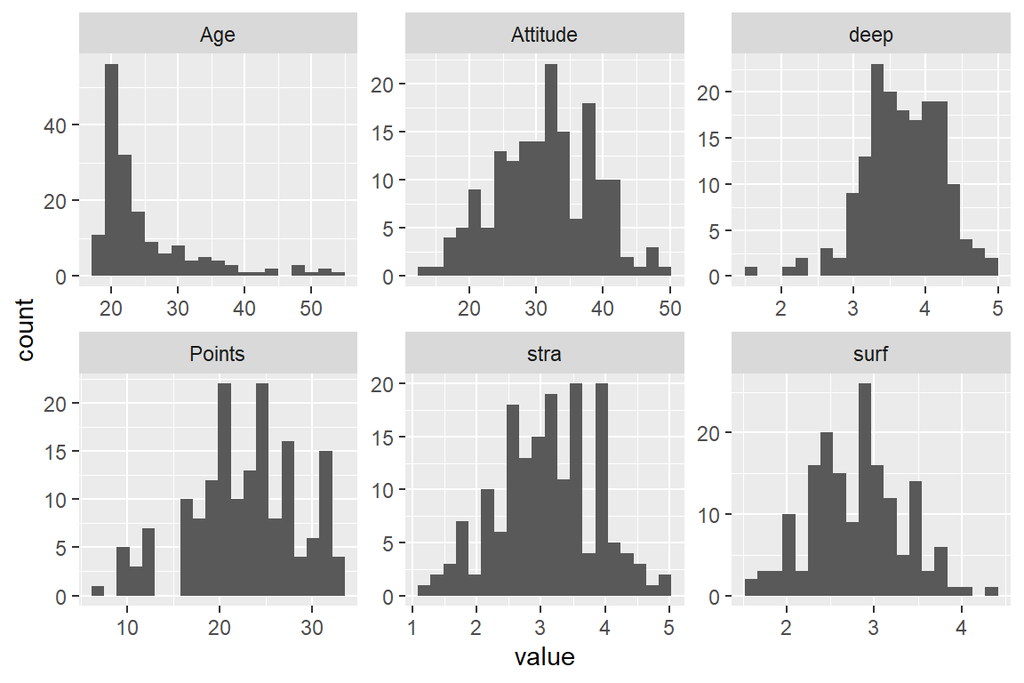

```r
library(GGally)
library(ggplot2)
library(dplyr)
library(tidyr)

#histograms for all numerical variables (so gender is not included):
students2014[,c(2:7)] %>%
  gather() %>%
  ggplot(aes(x=value)) + geom_histogram(bins = 20) + facet_wrap('key', scales='free')
```

Interpretation of information in the plotted histograms: except for the right skewed distribution of age, all the variables seem to be quite normally distributed, although the distributions are not quite even, but have some gaps and peaks in the middle. However, some of those gaps and peaks may look too wide due to settings in the plotting function. Maybe the QQ-plots give some additional accuracy to this.

### QQ-plots

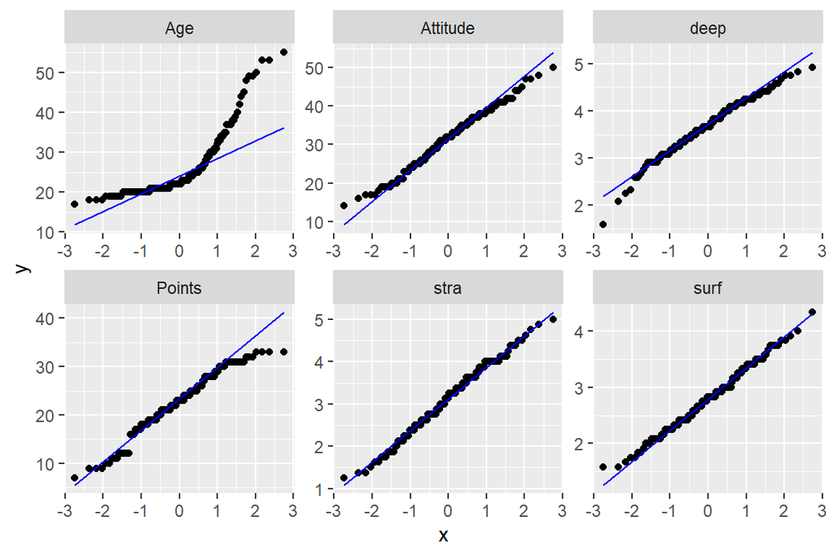

```r
library(GGally)
library(ggplot2)
library(dplyr)
library(tidyr)


#qq-plots:
students2014[,c(2:7)] %>%
  gather() %>%
  ggplot(aes(sample=value)) +
  geom_qq() +
  geom_qq_line(colour = "blue") +
  facet_wrap('key', scales='free')
```

Interpretation of the QQ-plots: according to the QQ-plots, age-variable does not seem to be normally distributed, and the points-variable is also at the limit of whether it is normally distributed, since the higher end diverges from the line. Other QQ-plots, instead, support the evidence of normal distribution observed in histograms earlier.

### Box plots

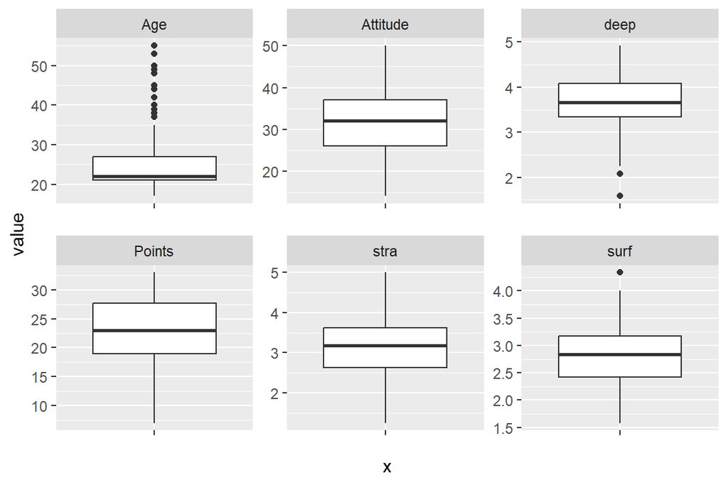

```r
library(GGally)
library(ggplot2)
library(dplyr)
library(tidyr)

students2014[,c(2:7)] %>%
  gather() %>%
  ggplot(aes(y=value, x='')) +
  geom_boxplot() +
  facet_wrap('key', scales='free')
```

Interpretation of the boxplots: typically, boxplots are used to compare for example median or range of a continuous variable between different categories, but here I used it just to show how are the median value and other values located within the 1.5 times interquartile range area and if there are outliers. Boxplots of age, deep and surf show that there are some potential outliers, the dots outside the the whiskers. Also, uneven lengths of whiskers in age and points boxplots can indicate some deviation or skewness in the (normal) distribution of these variables.

### Correlation of variable pairs + extra plots

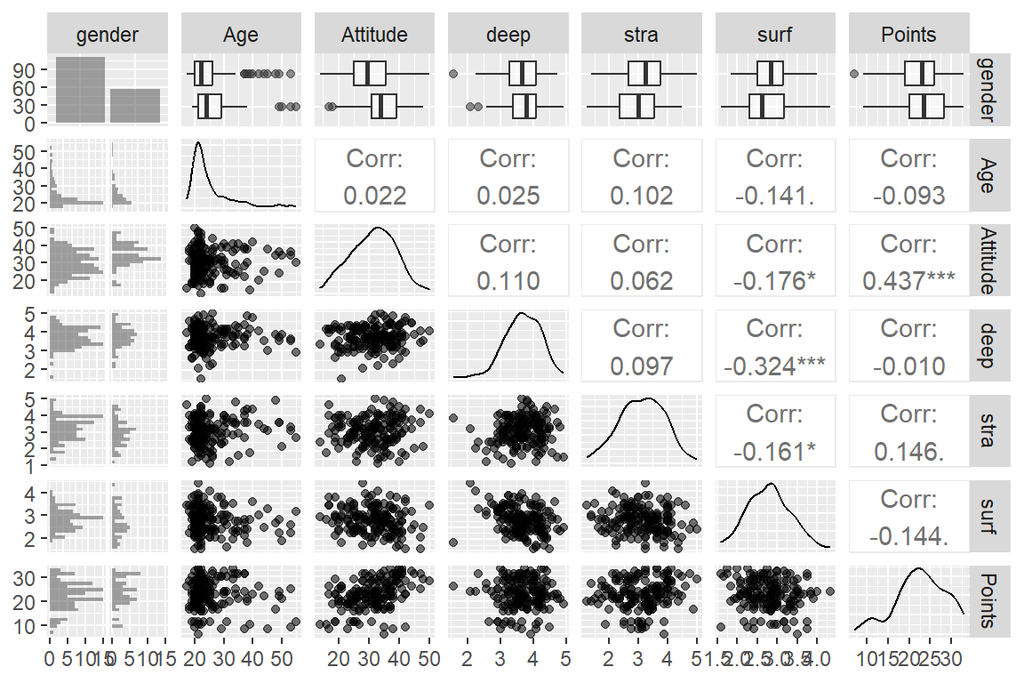

```r
library(GGally)
library(ggplot2)
library(dplyr)
library(tidyr)

#ggpairs from ggplot2-package will form all combinations of pairs from the variables in the data and plot their
p2 <- ggpairs(students2014, mapping = aes(alpha = 0.3), lower = list(combo = wrap("facethist", bins = 20)))
p2
```

Interpretation of ggpairs output: here we can see histograms, boxplots and scatter plots drawn for each categorical variable by gender (the only categorical variable) and also density plots. I, however, drew this graph because of paired correlation tests. The more the Corr-titled value of two variables differs from zero, the stronger correlation, or dependence there may be between them. However, the correlation should be interpreted carefully as it may only be apparent rather than a real dependency. The relationship is not necessarily causal either. The strongest correlations seem to be between Attitude and Points pair and between surf and deep pair. Weakest correlations seem be between Attitude and Age pair and deep and Points pair.

## 3. Linear regression

### Linear regression model using exam points as dependent variable and attitude, stra(tegic learning) and surf(ace learning) as explanatory variables

With this I will study if there are statistically significant linear relationship type association between exam points and attitude or the chosen learning strategy scores and if some or all of them could be used as estimates exam points value.

```r
#Linear model fitting with chosen dependent variable: Points, and explanatory variables: Attitude, stra and surf
exampoints1 = lm(Points ~ Attitude + stra + surf, data = students2014)
summary(exampoints1)
```

```
##
## Call:
## lm(formula = Points ~ Attitude + stra + surf, data = students2014)
##
## Residuals:
##      Min       1Q   Median       3Q      Max
## -17.1550  -3.4346   0.5156   3.6401  10.8952
##
## Coefficients:
##             Estimate Std. Error t value Pr(>|t|)
## (Intercept) 11.01711    3.68375   2.991  0.00322 **
## Attitude     0.33952    0.05741   5.913 1.93e-08 ***
## stra         0.85313    0.54159   1.575  0.11716
## surf        -0.58607    0.80138  -0.731  0.46563
## ---
## Signif. codes:  0 '***' 0.001 '**' 0.01 '*' 0.05 '.' 0.1 ' ' 1
##
## Residual standard error: 5.296 on 162 degrees of freedom
## Multiple R-squared:  0.2074, Adjusted R-squared:  0.1927
## F-statistic: 14.13 on 3 and 162 DF,  p-value: 3.156e-08
```

#Interpretation of results of exampoints1-model: * Residuals: median of residual is quite nearby zero and 1Q and 3Q quite equally far from the median, but I think that the distribution of the residuals could be good to check, if the normality assumption of their distribution is actually fulfilled and the linear model is valid. * Coefficients and the statistical test: to see if there is a statistically significant association between the dependent and explanatory variable, t-test is used to test if the null hypothesis, slope (or beta1 in the linear regression equation), is zero or not. To calculate this t-value, the coefficient estimate, one for each explanatory variable, seen under the title ‘Estimate’ in the lm-summary table is divided by its (referring to the coefficient estimate value) standard error (‘Std.Error’), like this: ‘Estimate’/‘Std.Error’ = ‘t value’, so, for example to the Attitude-variable, the t-value can be calculated as follows: 0.33952/0.05741 = 5.913952. The p-value, probability of getting at least the t-value (just absolute amount matters) estimated, in turn, can be calculated based on or estimated from the t-distribution. For the p-value estimation, information about degrees of freedom and if the t-test is one or two tailed is needed in addition to the t-value. In our regression analysis, there are 162 degrees of freedom, and according to the sources listed below as well as estimated p-values, we used two-tailed t-test. To summarize the results shown in the ‘Coefficient’ part of the lm-summary-table, I could say that there is statistically significant association (p-value < 0.05) between the explanatory variable Attitude and the dependent variable Points. Other explanatory variables do not have statistically significant association with the Points. Here are the outside course material sources I used in the t-test interpretation: [t-test_linear_regression](https://www.statology.org/t-test-linear-regression/#:~:text=Linear%20regression%20is%20used%20to%20quantify%20the%20relationship,by%20performing%20a%20t-test%20for%20the%20regression%20slope.)(visited 13.11.2023), [p_value_and_t_value](https://www.statology.org/t-value-vs-p-value/#:~:text=For%20each%20test%2C%20the%20t-value%20is%20a%20way,data%20if%20the%20null%20hypothesis%20is%20actually%20true.)(visited 13.11.2023) and [p_value_from_t_statistic](https://www.statology.org/p-value-from-t-statistic/)(visited 13.11.2023)

```r
# Since Attitude was the only explanatory variable that was statistically significantly associated with the depended variable, Points, I remove surf and stra from the model and fit here a new model including only the Points and Attitude:
exampoints2 = lm(Points ~ Attitude, data = students2014)
summary(exampoints2)
```

```
##
## Call:
## lm(formula = Points ~ Attitude, data = students2014)
##
## Residuals:
##      Min       1Q   Median       3Q      Max
## -16.9763  -3.2119   0.4339   4.1534  10.6645
##
## Coefficients:
##             Estimate Std. Error t value Pr(>|t|)
## (Intercept) 11.63715    1.83035   6.358 1.95e-09 ***
## Attitude     0.35255    0.05674   6.214 4.12e-09 ***
## ---
## Signif. codes:  0 '***' 0.001 '**' 0.01 '*' 0.05 '.' 0.1 ' ' 1
##
## Residual standard error: 5.32 on 164 degrees of freedom
## Multiple R-squared:  0.1906, Adjusted R-squared:  0.1856
## F-statistic: 38.61 on 1 and 164 DF,  p-value: 4.119e-09
```

## 4. Explaining the relationship of the dependent variable and the explanatory variables and interpreting the multiple R squared results

```r
#I would interpret here the original linear model (including also non-significant explanatory variables) summary table:
summary(exampoints1)
```

```
##
## Call:
## lm(formula = Points ~ Attitude + stra + surf, data = students2014)
##
## Residuals:
##      Min       1Q   Median       3Q      Max
## -17.1550  -3.4346   0.5156   3.6401  10.8952
##
## Coefficients:
##             Estimate Std. Error t value Pr(>|t|)
## (Intercept) 11.01711    3.68375   2.991  0.00322 **
## Attitude     0.33952    0.05741   5.913 1.93e-08 ***
## stra         0.85313    0.54159   1.575  0.11716
## surf        -0.58607    0.80138  -0.731  0.46563
## ---
## Signif. codes:  0 '***' 0.001 '**' 0.01 '*' 0.05 '.' 0.1 ' ' 1
##
## Residual standard error: 5.296 on 162 degrees of freedom
## Multiple R-squared:  0.2074, Adjusted R-squared:  0.1927
## F-statistic: 14.13 on 3 and 162 DF,  p-value: 3.156e-08
```

As already mentioned, the only statistically significantly associated explanatory variable in this model was Attitude. The association seems to be positive, due to positive value of ‘Estimate’, so when the value of Attitude increases also the value of Points should increase, if this model is valid (linear regression assumptions fulfilled, these are evaluated in later section) and linear relationship actually exists. But according to this model, when Attitude increases, Points increases, and similarly, when the value of Attitude decreases, the Points also decreases. The ‘Estimate’ describes to slope of the regression line, and in the plot there would be Points on the y-axis and Attitude on the x-axis. In practice, when the value of x, or Attitude, increases one unit, Points (value) increases the amount of ‘Estimate’, which is 0.33952 per each Attitude unit.

The other explanatory variables are not statistically significant, and I would say, that they does not matter in the analysis or prediction of the dependent variable and remove them from the final prediction model. However, If the variables had been statistically significantly associated, I would have interpret the result that the relationship between stra and Points would have also been positive, so when one increases or decreases, the other does the same, and the relationship between the surf and Points would have been negative, meaning that when Points increases the surf value decreases and vice versa.

R squared and the penalized version of it, the adjusted R squared (this may the multiple R squared asked in the task, since each variable with no significant effect to the dependent variable will lower this adjusted R squared values), measures how well the data is fitted by a model. It’s also interpreted as how much of the variance of the dependent variable is explained by the explanatory variables. According to these measures, the part of variation of dependent variable explained by the explanatory variables is about 0.2 (from 1.0, which would be all variance of the dependent variable). This does not seem very huge part of variation explained or not very good fit of the data by the model, but the interpretation whether it’s clinically significant (or useful result in practice) may depend on many things I’m not able to evaluate here.

## 5. Diagnostic plots and interpretation of model assumptions

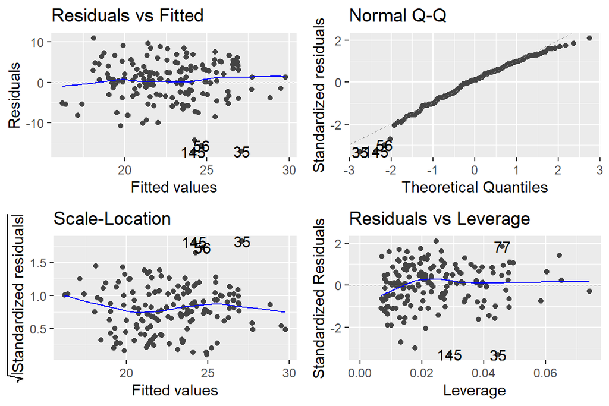

```r
library(ggfortify)
#I will use autoplot from ggfortify to produce the asked plots: Residuals vs Fitted values, Normal QQ-plot and Residuals vs Leverage
autoplot(exampoints1)
```

The assumptions of the model are: 1. Linear relationship between the dependent and explanatory variables: this would be best observed from a plotting a simple scatter plot of dependent versus explanatory variables with fitted line to see, if the there is a slope and the dots are located nicely around the line, following the trend. 2. Independence of residuals, followed from the assumption of independent observations: ideally, the dots in the Residual vs Fitted plot should be randomly spread around the area. In this case, I would say that the dots are quite randomly located in the Residuals vs Fitted plot, so the assumption is fulfilled. 3. Normal distribution of residuals: from the QQ-plot of residuals (’Normal QQ-titled plot) we can see that the dots mostly settle quite well on the line, but there is some dispersion at both ends of the line. The dispersion may still be within acceptable limits and the distribution would then fulfill the assumption of normality. 4. Equal variance of residuals, which can also be observed from the Residuals vs Fitted plot: this assumption is fulfilled if the dots seem to be equally far or close the line both on the left side and right side on the figure. I think that’s true in the Residuals vs Fitted plot.

The Residuals vs Leverage plot helps to find out if there are some influential observations that, if removed from the data, would affect a lot to the the model fit (as well as affect it if kept in the data, I guess). They can be outliers that should be removed, but at least they should be checked if they are errors, for instance. In the source (second source below) that I studied this plot type, there were some “Cook’s distance” limited areas, which showed the very influential observations, but I can’t see those dashed lines in the plot I created using autoplot. It seems, however, that high leverage and very low or high standardized residual value (as location) would be a bad thing, meaning that the dot would be located inside the Cook’s distance which refers to very influential observation, in the example plots (check the second source below). I interpret that my Residual vs Leverage plot does not include very influential observations.

More information related to the Residuals vs Fitted plot was found [here](https://www.statisticshowto.com/residual-plot/#:~:text=A%20residual%20plot%20has%20the%20Residuas%20on%20the,axis%3B%20the%20horizontal%20axis%20displays%20the%20independent%20variable.) (visited 13.11.2023). From [here](https://www.statology.org/diagnostic-plots-in-r/) I found more information about the interpretation of Residuals vs Leverage plot (visited 14.11.2023).

# 3: Logistic regression: analysis

```r
date()
```

```
## [1] "Tue Dec 12 03:39:13 2023"
```

```r
library(dplyr)
library(finalfit)
library(patchwork)
library(ggplot2)
library(GGally)
library(tidyr)
library(boot)
```

## 2. Data, variables and a short description

I read the data from my local data folder. I’m in the IODS-project folder at the moment of reading the data.

```r
alc = read.csv("data/alc.csv", sep = ";")
dim(alc)
```

```
## [1] 370  35
```

```r
str(alc)
```

```
## 'data.frame':    370 obs. of  35 variables:
##  $ school    : chr  "GP" "GP" "GP" "GP" ...
##  $ sex       : chr  "F" "F" "F" "F" ...
##  $ age       : int  18 17 15 15 16 16 16 17 15 15 ...
##  $ address   : chr  "U" "U" "U" "U" ...
##  $ famsize   : chr  "GT3" "GT3" "LE3" "GT3" ...
##  $ Pstatus   : chr  "A" "T" "T" "T" ...
##  $ Medu      : int  4 1 1 4 3 4 2 4 3 3 ...
##  $ Fedu      : int  4 1 1 2 3 3 2 4 2 4 ...
##  $ Mjob      : chr  "at_home" "at_home" "at_home" "health" ...
##  $ Fjob      : chr  "teacher" "other" "other" "services" ...
##  $ reason    : chr  "course" "course" "other" "home" ...
##  $ guardian  : chr  "mother" "father" "mother" "mother" ...
##  $ traveltime: int  2 1 1 1 1 1 1 2 1 1 ...
##  $ studytime : int  2 2 2 3 2 2 2 2 2 2 ...
```

[output cut: 21 more lines]

```r
#printing out the colnames
colnames(alc)
```

```
##  [1] "school"     "sex"        "age"        "address"    "famsize"
##  [6] "Pstatus"    "Medu"       "Fedu"       "Mjob"       "Fjob"
## [11] "reason"     "guardian"   "traveltime" "studytime"  "schoolsup"
## [16] "famsup"     "activities" "nursery"    "higher"     "internet"
## [21] "romantic"   "famrel"     "freetime"   "goout"      "Dalc"
## [26] "Walc"       "health"     "failures"   "paid"       "absences"
## [31] "G1"         "G2"         "G3"         "alc_use"    "high_use"
```

The original two data sets include mathematics and Portuguese languge performance information of students in two secondary education level Portuguese schools. The performance value is stored in the grade variables named as G1, G2 and G3, which also tells. G1 grade is from period 1, G2 from period 2 an G3 from period 3 and it is expected to have high correlation with the G1 and G2. In addition of grades, there are a lot of other variables related to the background, environment, behavior and characteristics of the students, such as alcohol consumption, absences, sex, age etc. More information about the data as well as the original data can be found and downloaded [here](http://www.archive.ics.uci.edu/dataset/320/student+performance) (visited 20.11.2023) This alc dataset is, however, combination of the two performance data sets. Background information is used to join the information from same students, and only common students included in both original data sets were kept in the ‘alc’ data. In this ‘alc’ data the grades are mean values of the two school subjects (mathematics and Portuguese language grades combined). Failures and absences are also mean values from the two data sets, alc_use is mean alcohol use of weekday and weekend use, high_use is a boolean variable depending on the average alcohol consumption (high use = more than two portions per week) and paid variable comes from mathematics data.

## 3. Four interesting variables and my hypotheses

There are so many interesting explanatory variables, but if I have to choose only four, I will choose:

1. absences - number of school absences (numeric: from 0 to 93) Hypothesis: those who are more absent may use more alcohol.
2. goout - going out with friends (numeric: from 1 - very low to 5 - very high) Hypothesis: those who spend a lot of time out with friends would probably use more alcohol due to social pressure than those who go out less
3. famrel - quality of family relationships (numeric: from 1 - very bad to 5 - excellent) Hypothesis: those who have good relationship with their family would more probably use less alcohol
4. health - current health status (numeric: from 1 - very bad to 5 - very good) Hypothesis: If a young adult does not feel healthy, which can be, for example, due to mental illness or chronic pain, the person would more probably use more alcohol.

I interpret more alcohol consumption, high_use = TRUE, as bad or worse outcome compared to the less alcohol consumption, in which high_use = FALSE.

## 4. Numerical and graphical exploration of the chosen variables’s distributions and relationship with alcohol consumption

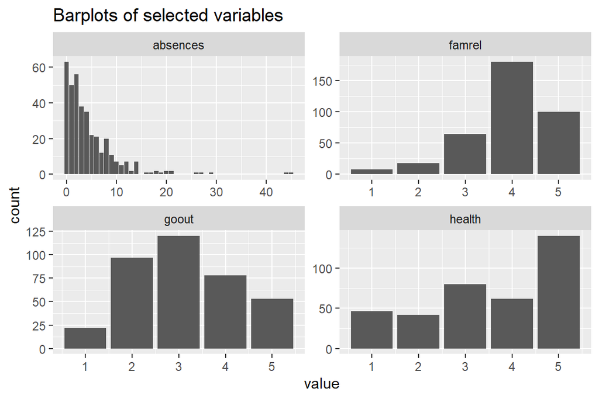

```r
chosen_var = c("absences", "goout", "health", "famrel")

#Barplots to see overall distribution of variables (not against any other variable at this point)
gather(alc[,chosen_var]) %>% ggplot(aes(value)) + geom_bar() + ggtitle("Barplots of selected variables") + facet_wrap("key", scales = "free")
```

#### Barplots of selected variables:

Here we can see distributions of the selected variables in the whole data.Students are not evenly distributed over any of the variables. According to these, “worse” values, which I hypothesized to be related to more alcohol consumption (smaller value in health or famrel, higher value in absences and goout) seem to be generally less frequent. Hypothesized “good” or “better” values, in turn, seem to be more frequent among these young adults. In the goout variable, there are more average answers (option 3) than in other variables, where the answers are focused on the “good” end (from my hypothesis point of view) of the distributions.

```r
#Tabulation of variables:
#- mean values of variables in the groups defined by dependent variable (high_use of alcohol)
#- relationship of each variable (in the tab1) and each category of each variable (tab2) with the dependent variable (high_use)

#tab1
dependent <- "high_use"
explanatory <- chosen_var
alc %>%
  summary_factorlist(dependent, explanatory, p = TRUE,
                     add_dependent_label = TRUE)
```

```
##  Dependent: high_use               FALSE      TRUE      p
##             absences Mean (SD) 3.7 (4.5) 6.4 (7.1) <0.001
##                goout Mean (SD) 2.9 (1.0) 3.7 (1.1) <0.001
##               health Mean (SD) 3.5 (1.4) 3.7 (1.4)  0.134
##               famrel Mean (SD) 4.0 (0.9) 3.8 (0.9)  0.019
```

```r
#tab2: to this table I create another data frame that includes the categorical variables of interest as factors that I can see the relationship of each group. This enables more detailed evaluation of relationships of those explanatory and dependent variables.
alc_f = alc
alc_f$goout = as.factor(alc$goout)
alc_f$health = as.factor(alc$health)
alc_f$famrel = as.factor(alc$famrel)

explanatory_f <- c("absences" ,"goout",    "health" ,  "famrel")
alc_f %>%
  summary_factorlist(dependent, explanatory_f, p = TRUE,
                     add_dependent_label = TRUE)
```

```
##  Dependent: high_use                FALSE      TRUE      p
##             absences Mean (SD)  3.7 (4.5) 6.4 (7.1) <0.001
##                goout         1   19 (7.3)   3 (2.7) <0.001
##                              2  82 (31.7) 15 (13.5)
##                              3  97 (37.5) 23 (20.7)
##                              4  40 (15.4) 38 (34.2)
##                              5   21 (8.1) 32 (28.8)
##               health         1  35 (13.5)  11 (9.9)  0.298
##                              2  28 (10.8) 14 (12.6)
##                              3  61 (23.6) 19 (17.1)
##                              4  45 (17.4) 17 (15.3)
##                              5  90 (34.7) 50 (45.0)
##               famrel         1    6 (2.3)   2 (1.8)  0.076
##                              2    9 (3.5)   9 (8.1)
##                              3  39 (15.1) 25 (22.5)
##                              4 128 (49.4) 52 (46.8)
##                              5  77 (29.7) 23 (20.7)
```

#### Tab1:

Tab1 shows the relationship between dependent variable (high_use) and explanatory variables (the selected four variables), and also mean value and standard deviations of the explanatory variables in the groups of dependent variable. P-value is a result from one or another statistical test (which can be read more from [here](https://finalfit.org/reference/summary_factorlist.html), visited 20.11.2023) and shows if there is statistically significant relationship between the dependent and expalantory variables. It can be utilized when evaluating which explanatory variables should be included in the model. In this tab1, we can see that there are statistically significant relationships between the dependent variable and abscences, goout and famrel, but not with health. The overal group specific mean values of the explanatory variables also indicate that on average, those who belong to group high_use = FALSE, act and feel differently about these factors than those who belong to the high_use = TRUE group.

#### Tab2:

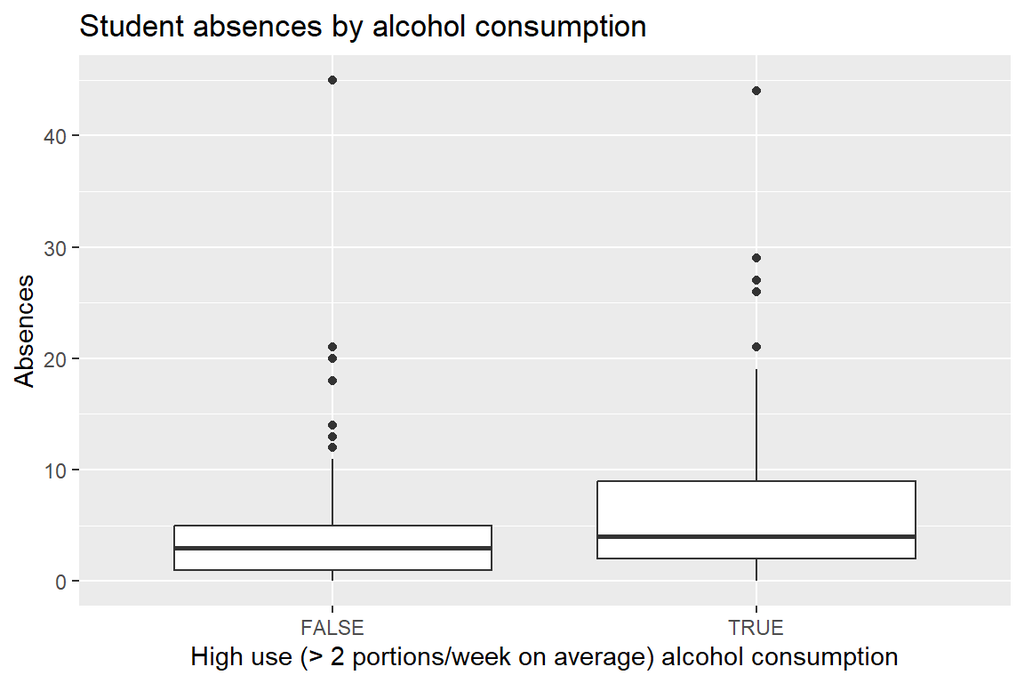

```r
#Graphical exploration of each variable
#for the continuous absence variable against categorical high_use dependent variable I will visualize the relationship using boxplot
g2 <- ggplot(alc, aes(x = high_use, y = absences))

# define the plot as a box plot and draw it
g2 = g2 + geom_boxplot() + xlab("High use (> 2 portions/week on average) alcohol consumption") + ylab("Absences") + ggtitle("Student absences by alcohol consumption")
g2
```

#### Student absences by alcohol consumption -boxplot for continuous absences variable against categorical high_use variable

The boxplot shows that also medians (means were seen to differ in the tab1 and tab2) differ between high_use categorized absences. From the difference in the size of the boxes and the length of the whiskers, as well as the placement on the y-axis, we can also conclude that the distributions of the absences differ between the groups. This may cause some unstability to the resuls, or may not. There also seem to be some outliers in high end of the absences variable in both high_use categories. I can consider removal of them before the regression analysis.

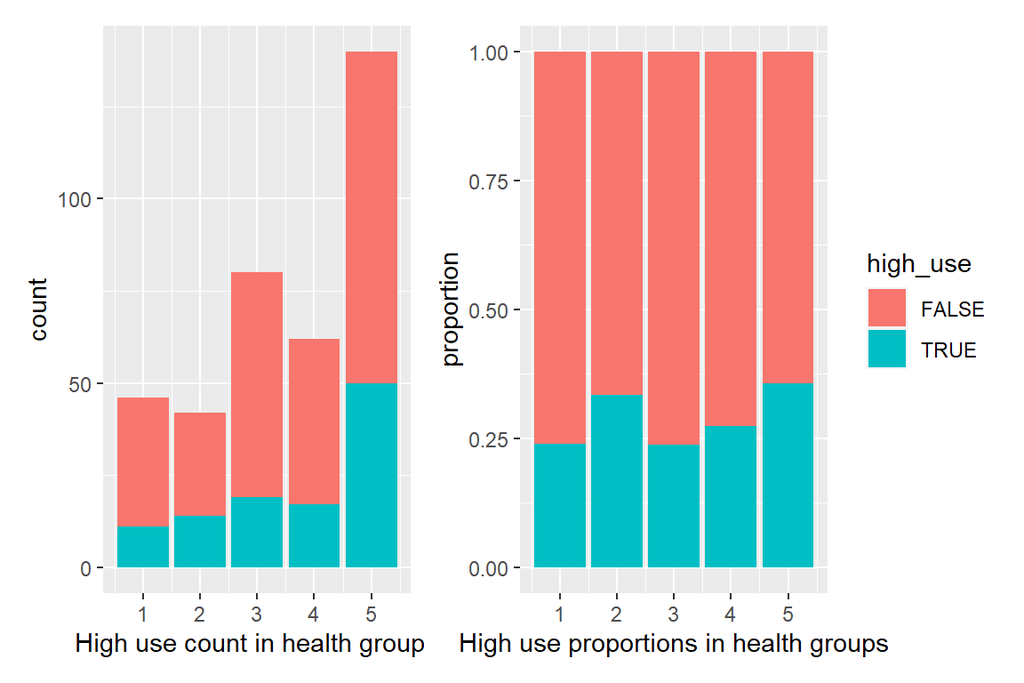

```r
#group specific barplots for categorical health, goout and famrel variables groupped by the categorical high_use (dependent) variable

#high users in health different groups of health anwerers

p1 <- alc %>%
  ggplot(aes(x = health, fill = high_use)) +
  geom_bar() +
  theme(legend.position = "none") + xlab("High use count in health groups")

p2 <- alc %>%
  ggplot(aes(x = health, fill = high_use)) +
  geom_bar(position = "fill") +
  ylab("proportion") +
  xlab("High use proportions in health groups")

p1 + p2
```

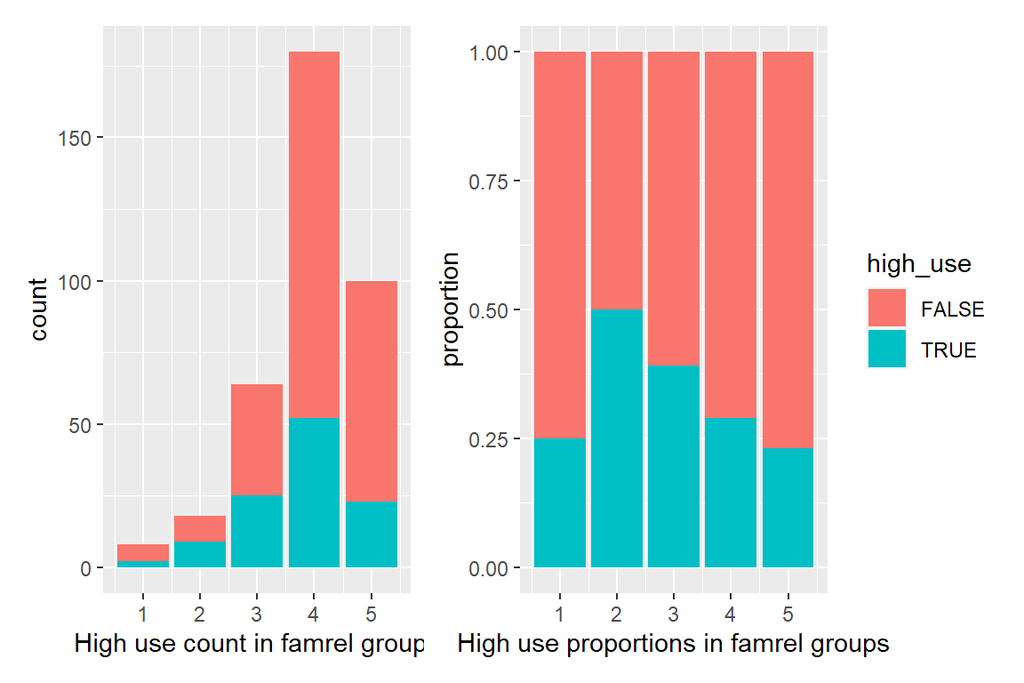

```r
#famrel and high_use
p3 <- alc %>%
  ggplot(aes(x = famrel, fill = high_use)) +
  geom_bar() +
  theme(legend.position = "none") + xlab("High use count in famrel groups")

p4 <- alc %>%
  ggplot(aes(x = famrel, fill = high_use)) +
  geom_bar(position = "fill") +
  ylab("proportion") +
  xlab("High use proportions in famrel groups")

p3 + p4
```

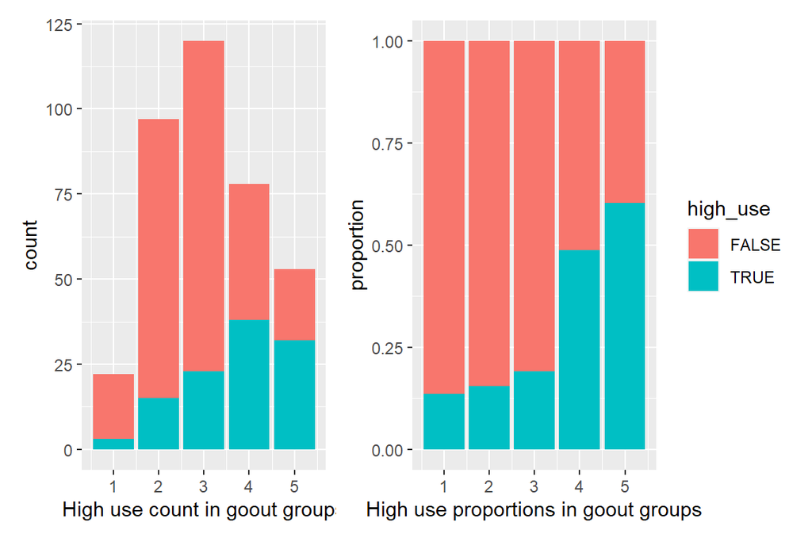

```r
#goout and high_use
p5 <- alc %>%
  ggplot(aes(x = goout, fill = high_use)) +
  geom_bar() +
  theme(legend.position = "none") + xlab("High use count in goout groups")

p6 <- alc %>%
  ggplot(aes(x = goout, fill = high_use)) +
  geom_bar(position = "fill") +
  ylab("proportion") +
  xlab("High use proportions in goout groups")

p5 + p6
```

#### Barplots of categorical explanatory and dependent varibles: high_use categorization of categorical explanatory variables (health, goout and famrel) categories

From the first barplots containing high_use counts (on the left) and proportions (on the right) in different health answer categories (1=worse health, 5=better health) we can see that the proportion of students classified as ‘high users’ of alcohol is quite equal in each health group. I would deduce that the health status does not affect much to the student’s alcohol usage. In the second barpolot describing family relationship (1=worse, 5=better) and alcohol consumptin in these answer groups, we can see a slight shift to the right in the proportion distribution of high_use = TRUE. I would interpret that a little bit higher proportion of those with worse family relationship are classified as ‘high users’ of alcohol compared to those with better family relationships. However, this assumption may be unstable as we see in the count-figure (left side plot) and in the tab2 earlier, that there is very low amount of high-use observations in the famrel-group 1. We may thus have too little example of group 1 to make accurate enough approximations about the relationship of variables in this group.

## 5. Fitting logistic regression model and interpreting the results

```r
#fit the logistic regression model (m) using high_use as dependent variable and the selected four variables as explanatory variables
# I will use the data where I have the factor variables in the actual factor form (they include levels 1-5)
m <- glm(high_use ~ absences + health + famrel + goout, data = alc_f, family = "binomial")

#summary of the model:
summary(m)
```

```
##
## Call:
## glm(formula = high_use ~ absences + health + famrel + goout,
##     family = "binomial", data = alc_f)
##
## Deviance Residuals:
##     Min       1Q   Median       3Q      Max
## -1.8068  -0.7339  -0.4964   0.8587   2.2526
##
## Coefficients:
##             Estimate Std. Error z value Pr(>|z|)
## (Intercept) -2.75707    1.12482  -2.451 0.014241 *
## absences     0.07072    0.02199   3.216 0.001301 **
## health2      0.51161    0.55080   0.929 0.352966
## health3      0.42814    0.50533   0.847 0.396855
## health4      0.32818    0.51456   0.638 0.523617
## health5      0.93999    0.45406   2.070 0.038436 *
## famrel2      0.31119    1.04108   0.299 0.765008
## famrel3      0.30873    0.93600   0.330 0.741522
## famrel4     -0.47947    0.91426  -0.524 0.599977
## famrel5     -0.88881    0.93289  -0.953 0.340719
## goout2       0.44555    0.75105   0.593 0.553024
## goout3       0.79124    0.73485   1.077 0.281595
## goout4       2.22838    0.74004   3.011 0.002603 **
## goout5       2.65436    0.75782   3.503 0.000461 ***
## ---
## Signif. codes:  0 '***' 0.001 '**' 0.01 '*' 0.05 '.' 0.1 ' ' 1
##
## (Dispersion parameter for binomial family taken to be 1)
##
##     Null deviance: 452.04  on 369  degrees of freedom
## Residual deviance: 369.75  on 356  degrees of freedom
## AIC: 397.75
##
## Number of Fisher Scoring iterations: 4
```

```r
#Estimates (coefficients) seen in the summary table are in log-odds scale and can be changed to odds-ratios by exponentiation.
# compute odds ratios (OR) to the explanatory variables in the fitted model m:
OR <- coef(m) %>% exp
#OR
# The confidence intervals for the ORs should also be calculated in the exponentiated scale.
#compute confidence intervals (CI)
CI = confint(m) %>% exp
#CI
# print out the odds ratios with their confidence intervals
cbind(OR, CI)
```

```
##                      OR       2.5 %     97.5 %
## (Intercept)  0.06347754 0.005363178  0.4879307
## absences     1.07328510 1.028800212  1.1230273
## health2      1.66796910 0.569507707  4.9967567
## health3      1.53440001 0.577932516  4.2357103
## health4      1.38843307 0.511780070  3.8933523
## health5      2.55996159 1.078350996  6.4598320
## famrel2      1.36504846 0.194194614 13.0412774
## famrel3      1.36169127 0.244297792 11.1264894
## famrel4      0.61911223 0.116058382  4.8915226
## famrel5      0.41114516 0.073648899  3.3259447
## goout2       1.56134288 0.404576318  8.3386634
## goout3       2.20613839 0.596347942 11.5095561
## goout4       9.28481119 2.497194937 48.9835440
## goout5      14.21583349 3.666926997 76.9157608
```

### Interpretation of logistic regression model, OR and CI results

#### Results presented variable by variable

Absences Absences was the only continuous variable in my model and it seem to be statistically significantly (p-value < 0.05) associated with the dependent variable (high_use). Odds-ratio for absences is ~1.07. The Health Data Science book (Ewen Harrison and Riinu Pius, 2021, chapter: 9.2 Binary logistic regression) has the following interpretation for the relationship of the OR of continuous variable and binary dependent variable: “the odds ratio is the change in odds of a CV event associated with a 1 cup increase in coffee consumption”. Based on this, I would interpret the relationship between absence and high_use as follows: per each time of absence, the odds of high use event occurrence increases by ~1.07. I would say that it becomes more probable to become as a ‘high user’ of alcohol per each absence. However, this does not yet mean causality. High use event here means the situation where the average weekly consumption of alcohol is more than two portions. Confidence intervals (CI) for the absences seem to be quite narrow, referring to accurate estimate.Value 1 is not included in the CI, meaning that the values of log-odds do not vary from below the zero to more than zero, from which it follows that OR values do not vary from less than 1 to more than one. This means that the direction of the effect of the explanatory variable does not change and the relationship of the explanatory variable and dependent variable can be statistially significant. The result: ‘the more absences the more probable to become high user of alcohol’ is in line with my hypothesis.

Other explanatory variables in my model are categorical. About the relationship of categorical explanatory variables and categorical dependent variable the same book and chapter (The Health Data Science, Ewen Harrison and Riinu Pius, 2021, chapter: 9.2 Binary logistic regression) referred earlier say that: “odds ratio is the change in odds of a CV event associated with smoking compared with not smoking (the reference level)”. In this case, however I have five categories in each explanatory variable instead of two (in binary variable). I would also utilize information from [stackexchange](https://stats.stackexchange.com/questions/60817/significance-of-categorical-predictor-in-logistic-regression)(visited 20.11.2023), this source was found in task 3 instructions) in my result interpretation. The model uses class 1 of my categorical explanatory variables (health, goout and famrel) as reference level. According to the [stackexchange](https://stats.stackexchange.com/questions/60817/significance-of-categorical-predictor-in-logistic-regression)(visited 20.11.2023), Wald test is used to compare if the difference of coefficients between each of the reference and other class pairs (which are e.g. coefficient of goout1-coefficient of goout2, coeffiecient of goout1-coefficient of goout3 and so on for the goout variable) equals to zero or not. The statistical significance of the test means that difference of the of coefficients of reference and compared class is statistically significantly different from zero. The coefficient of reference equals to intercept and the coefficients of other classes are actually those seen under the ‘Estimate’ title in the summary table plus the intercept. Based on this introduction and also referencing to what I wrote earlier about OR and CI in general, I would interpret the result of health variable as follows: only the class five is statistically significant in the model. It means that the difference of coefficients of health = 1 and health = 5 groups significantly differs from zero in Wald test. OR for the group 5 is ~2.6, which is positive change in odds of becoming ‘high user’ of alcohol when a student has answered ‘health is very good’ compared to the situation when a student has answered ‘health is very bad’. So, the healthier the student, the more likely it is to become a heavy consumer of alcohol. This is not in line with my hypothesis, which was the opposite to this result. However, the confidence interval of this statistically significant OR result is very wide: from 1.078350996 to 6.4598320, meaning that the estimate is not very accurate. The accuracy of the estimate may be improved by using bigger sample size, so having more observations (=more students answering to the questionnaire).

In case of family relationships (famrel), there are no statistically significant relationships observed, so I do not interpret their results more.

For the goout variable, there seems to be even two classes that have achieved statistical significance in the Wald test. OR for class 4 compared to class 1 is: 9.28481119 it’s CI is: 2.497194937-48.9835440, and OR and CI for the class 5 compared to class 1 are: 14.21583349, and from 3.666926997 to 76.9157608, respectively. The positive change in odds of becoming ‘high user’ of alcohol is ~9.3 for the students who answered ‘high’ and ~14.2 for the students who answered ‘very high’ to the question about going out with friends compared to those who answered ‘very low’ to the same question. The CI seems to be very wide again for both of the class pair comparisons, so the estimates cannot be kept very accurate. However, in summary, it seems that those students who more go out with their friends are more likely to become heavy consumers of alcohol compared to those who much less go out with their friends. This is in line with my hypothesis.

AIC of the model, which describes the goodness of fit of the model, is 397.75. This does not tell much alone, but if we fit another model in the same data using, for example, only statistically significant variables, we can compare if the AIC of the model is smaller and the goodness of fit therefore improved, when non-significant extra variables are removed.

## 6. Prediction with the statistically significant variables and comparison of training error with simpler (guessing strategy) model

I will use absences, health and goout as explanatory variables in the prediction accuracy testing.

```r
# fit the model
m2 <- glm(high_use ~  absences + health + goout, data = alc_f, family = "binomial")

summary(m2)
```

```
##
## Call:
## glm(formula = high_use ~ absences + health + goout, family = "binomial",
##     data = alc_f)
##
## Deviance Residuals:
##     Min       1Q   Median       3Q      Max
## -1.8504  -0.6951  -0.5473   0.9275   2.1270
##
## Coefficients:
##             Estimate Std. Error z value Pr(>|z|)
## (Intercept) -2.95567    0.79998  -3.695  0.00022 ***
## absences     0.07308    0.02231   3.275  0.00106 **
## health2      0.54489    0.53221   1.024  0.30591
## health3      0.50617    0.48756   1.038  0.29919
## health4      0.32499    0.49461   0.657  0.51114
## health5      0.84086    0.43746   1.922  0.05459 .
## goout2       0.33251    0.74407   0.447  0.65496
## goout3       0.64066    0.72782   0.880  0.37873
## goout4       2.04100    0.72805   2.803  0.00506 **
## goout5       2.38920    0.74395   3.211  0.00132 **
## ---
## Signif. codes:  0 '***' 0.001 '**' 0.01 '*' 0.05 '.' 0.1 ' ' 1
##
## (Dispersion parameter for binomial family taken to be 1)
##
##     Null deviance: 452.04  on 369  degrees of freedom
## Residual deviance: 380.89  on 360  degrees of freedom
## AIC: 400.89
##
## Number of Fisher Scoring iterations: 4
```

```r
#health is not significant anymore
#just testing, if AIC is improved without health variable:
m3 = glm(high_use ~  absences + goout, data = alc_f, family = "binomial")
summary(m3)
```

```
##
## Call:
## glm(formula = high_use ~ absences + goout, family = "binomial",
##     data = alc_f)
##
## Deviance Residuals:
##     Min       1Q   Median       3Q      Max
## -1.8698  -0.6623  -0.5568   0.9296   2.1596
##
## Coefficients:
##             Estimate Std. Error z value Pr(>|z|)
## (Intercept) -2.37793    0.69537  -3.420 0.000627 ***
## absences     0.07409    0.02239   3.309 0.000937 ***
## goout2       0.38302    0.73393   0.522 0.601761
## goout3       0.59236    0.71646   0.827 0.408354
## goout4       1.95585    0.71438   2.738 0.006185 **
## goout5       2.37879    0.73265   3.247 0.001167 **
## ---
## Signif. codes:  0 '***' 0.001 '**' 0.01 '*' 0.05 '.' 0.1 ' ' 1
##
## (Dispersion parameter for binomial family taken to be 1)
##
##     Null deviance: 452.04  on 369  degrees of freedom
## Residual deviance: 385.61  on 364  degrees of freedom
## AIC: 397.61
##
## Number of Fisher Scoring iterations: 4
```

```r
# I will, however, do the predictions with the model 2 as health was statistically significant before and instructions told to choose statistically significant variables from that model.

# predict() the probability of high_use based on the model including (earlier) statistically significant explanatory variables
probabilities <- predict(m2, type = "response")

#probabilities
# add the predicted probabilities to 'alc_f' data as a new column called probability
alc_f <- mutate(alc_f, probability = probabilities)

# use the probabilities to make a prediction of high_use. If probability predicted for high_use is higher than 0.5, the prediction suggests, that the (predicted) high_use status of the student is high_use = TRUE and vice versa.
alc_f <- mutate(alc_f, prediction = probability > 0.5)

# see the last ten original classes, predicted probabilities, and class predictions
select(alc_f, absences, health, goout, high_use, probability, prediction) %>% tail(10)
```

```
##     absences health goout high_use probability prediction
## 361        3      3     3    FALSE   0.1694371      FALSE
## 362        0      5     2    FALSE   0.1440197      FALSE
## 363        7      3     3     TRUE   0.2146163      FALSE
## 364        1      4     3    FALSE   0.1282027      FALSE
## 365        6      5     3    FALSE   0.2619800      FALSE
## 366        2      5     2    FALSE   0.1629901      FALSE
## 367        2      1     4    FALSE   0.3167992      FALSE
## 368        3      5     1    FALSE   0.1306091      FALSE
## 369        4      2     5     TRUE   0.5672701       TRUE
## 370        2      5     1     TRUE   0.1225329      FALSE
```

```r
# tabulate the target variable versus the predictions
cross_table = table(high_use = alc_f$high_use, prediction = alc_f$prediction)
cross_table
```

```
##         prediction
## high_use FALSE TRUE
##    FALSE   235   24
##    TRUE     60   51
```

```r
#cross table as dataframe: just to clarify the numbers
cross_tab_as_df = as.data.frame(table(high_use = alc_f$high_use, prediction = alc_f$prediction))
rownames(cross_tab_as_df) = c("correct_false_pred", "incorrect_false_pred","incorrect_true_pred", "correct_true_pred")
cross_tab_as_df
```

```
##                      high_use prediction Freq
## correct_false_pred      FALSE      FALSE  235
## incorrect_false_pred     TRUE      FALSE   60
## incorrect_true_pred     FALSE       TRUE   24
## correct_true_pred        TRUE       TRUE   51
```

```r
#incorrectly predicted values:
(60+24)/370
```

```
## [1] 0.227027
```

```r
#0.227027
```

### Interpretation of prediction results

This time health variable seem to non-significant in the model, even if it was stastitically significant before. I think this just shows how uncertain the values with wide CIs were. However, I will keep in the prediction model as it was significant before. AIC is actually increased (from 397.75 to 400.89), suggesting that this model is not actually better than the earlier model. For the model without health variable, AIC would be:397.61, which is a little bit better value indicating better model fit than in case of the original model that included four variables.

I present here the cross tabulation of correct and incorrect predictions, but to clarify the numbers to myself, I also present another table about the correct and incorrect predictions. Prediction is classified as correctly predicted when the prediction gets the same value as the actual status of high_use is. So, correctly predicted status can be identified as prediction = FALSE and high_use = FALSE at the same row (student) or prediction = TRUE and high_use = TRUE. Other combinations seen on the same row are incorrect predictions.

It seems that of the 370 students, the prediction was correct FALSE for 235 students, correct TRUE for 51 students and incorrect FALSE for 60 students and incorrect TRUE for 24 students. In total, predictions of 60+24 = 84 students were wrong compared to the real high_use status. The training error was therefore 0.227027.

```r
#simpler guessing strategy model: I fit a model using only absences as explanatory variable and see what happens to the training error when I try to predict high_use status with this simple model
simple_m = glm(high_use ~  absences, data = alc_f, family = "binomial")
summary(simple_m)
```

```
##
## Call:
## glm(formula = high_use ~ absences, family = "binomial", data = alc_f)
##
## Deviance Residuals:
##     Min       1Q   Median       3Q      Max
## -2.3598  -0.8209  -0.7318   1.2658   1.7419
##
## Coefficients:
##             Estimate Std. Error z value Pr(>|z|)
## (Intercept) -1.26945    0.16094  -7.888 3.08e-15 ***
## absences     0.08867    0.02317   3.827  0.00013 ***
## ---
## Signif. codes:  0 '***' 0.001 '**' 0.01 '*' 0.05 '.' 0.1 ' ' 1
##
## (Dispersion parameter for binomial family taken to be 1)
##
##     Null deviance: 452.04  on 369  degrees of freedom
## Residual deviance: 434.52  on 368  degrees of freedom
## AIC: 438.52
##
## Number of Fisher Scoring iterations: 4
```

```r
OR <- coef(simple_m) %>% exp
CI = confint(simple_m) %>% exp
print("OR and CI of the simple model variables")
```

```
## [1] "OR and CI of the simple model variables"
```

```r
cbind(OR, CI)
```

```
##                    OR     2.5 %    97.5 %
## (Intercept) 0.2809874 0.2030806 0.3819961
## absences    1.0927146 1.0464586 1.1459894
```

```r
probabilities_simple <- predict(simple_m, type = "response")
alc_f <- mutate(alc_f, probability_simple = probabilities_simple)
alc_f <- mutate(alc_f, prediction_simple = probability_simple > 0.5)
cross_table_simple = table(high_use = alc_f$high_use, prediction = alc_f$prediction_simple)

#cross table of the simpler model
cross_table_simple
```

```
##         prediction
## high_use FALSE TRUE
##    FALSE   254    5
##    TRUE    102    9
```

```r
#training error:
(5+102)/370
```

```
## [1] 0.2891892
```

As can be seen, the training error or the proportion of incorrectly classified high_use statuses increases from 0.227027 of the more complicated model to 0.2891892 in the the simple model. The simple model here is very simple, using only one independent variable to prediction of the dependent variable statuses. The prediction result deteriorates despite the fact that the variable is very precise (according to narrow CIs) and statistically significant (p-value 0.00013 < 0.05).

## 7. Bonus: 10-fold cross-validation

```r
#Here I utilize the training error calculation function, called loos_func, from the Exercise3:
loss_func <- function(class, prob) {
  n_wrong <- abs(class - prob) > 0.5
  mean(n_wrong)
}

#For 10-fold cross-validation I use cv.glm-function from boot-package, also used in the Exercise3. K=10 tells to the function that I want to do the 10-fold cross-validation. I also offer the loss_func to the cv.glm that it can estimate the average prediction error for the whole cross-validation (ten rounds using different set of observations in validation at each round)
cv10 <- cv.glm(data = alc_f, cost = loss_func, glmfit = m2, K = 10)

# the average prediction error is stored in delta-value that can be extracted from the model using $-operator and indexing the first of the values in delta
cv10$delta[1]
```

```
## [1] 0.2675676
```